# Tutorial 4A - Feature Selection

## Week 4: Feature Selection

Reducing the complexity of the data can be done in two ways, `Feature Selection` and `Feature Transformation`. In this notebook, we will focus on `Feature Selection`. Feature Selection implies choosing a subset of the features from the original X.

#### When to opt for Feature Selection?

- Many X variables are present but **most** of which **contain little information** and some are very meaningful.
- The meaningful variables are independent of each other.

Here, we cover univariate feature selection (filters) using `mutual information` and `chi-sq` as well as wrapper techniques using `Sequential feature selection` available on scikit-learn and mlxtend packages respectively. However, there are more ways to implement feature selection on scikit-learn, refer to [documentation](https://scikit-learn.org/stable/modules/feature_selection.html#sequential-feature-selection) for details.

#### Import Packages

```python
import pandas as pd
from sklearn import datasets
from sklearn.metrics import accuracy_score
from sklearn.preprocessing import StandardScaler
from sklearn.model_selection import train_test_split

from sklearn.neighbors import KNeighborsClassifier
from sklearn.feature_selection import chi2, mutual_info_classif, SelectKBest
```

```python
# import wine dataset that is given by scikit-learn, 'as_frame=True' ensures to return the data as a dataframe
wine = datasets.load_wine(as_frame=True)
print(wine.DESCR)
```

```
.. _wine_dataset:

Wine recognition dataset
------------------------

**Data Set Characteristics:**

    :Number of Instances: 178 (50 in each of three classes)
    :Number of Attributes: 13 numeric, predictive attributes and the class
    :Attribute Information:
 		- Alcohol
 		- Malic acid
 		- Ash
		- Alcalinity of ash
 		- Magnesium
		- Total phenols
 		- Flavanoids
 		- Nonflavanoid phenols
 		- Proanthocyanins
		- Color intensity
 		- Hue
 		- OD280/OD315 of diluted wines
 		- Proline

    - class:
            - class_0
            - class_1
            - class_2

    :Summary Statistics:

    ============================= ==== ===== ======= =====
                                   Min   Max   Mean     SD
    ============================= ==== ===== ======= =====
    Alcohol:                      11.0  14.8    13.0   0.8
    Malic Acid:                   0.74  5.80    2.34  1.12
    Ash:                          1.36  3.23    2.36  0.27
    Alcalinity of Ash:            10.6  30.0    19.5   3.3
    Magnesium:                    70.0 162.0    99.7  14.3
    Total Phenols:                0.98  3.88    2.29  0.63
```

[output cut: 40 more lines]

```
  Tech. Rep. no. 92-02, (1992), Dept. of Computer Science and Dept. of
  Mathematics and Statistics, James Cook University of North Queensland.
  (Also submitted to Technometrics).

  The data was used with many others for comparing various
  classifiers. The classes are separable, though only RDA
  has achieved 100% correct classification.
  (RDA : 100%, QDA 99.4%, LDA 98.9%, 1NN 96.1% (z-transformed data))
  (All results using the leave-one-out technique)

  (2) S. Aeberhard, D. Coomans and O. de Vel,
  "THE CLASSIFICATION PERFORMANCE OF RDA"
  Tech. Rep. no. 92-01, (1992), Dept. of Computer Science and Dept. of
  Mathematics and Statistics, James Cook University of North Queensland.
  (Also submitted to Journal of Chemometrics).
```

```python
X = wine.data
X.head()
```

|  | alcohol | malic_acid | ash | alcalinity_of_ash | magnesium | total_phenols | flavanoids | nonflavanoid_phenols | proanthocyanins | color_intensity | hue | od280/od315_of_diluted_wines | proline |
| --- | --- | --- | --- | --- | --- | --- | --- | --- | --- | --- | --- | --- | --- |
| 0 | 14.23 | 1.71 | 2.43 | 15.6 | 127.0 | 2.80 | 3.06 | 0.28 | 2.29 | 5.64 | 1.04 | 3.92 | 1065.0 |
| 1 | 13.20 | 1.78 | 2.14 | 11.2 | 100.0 | 2.65 | 2.76 | 0.26 | 1.28 | 4.38 | 1.05 | 3.40 | 1050.0 |
| 2 | 13.16 | 2.36 | 2.67 | 18.6 | 101.0 | 2.80 | 3.24 | 0.30 | 2.81 | 5.68 | 1.03 | 3.17 | 1185.0 |
| 3 | 14.37 | 1.95 | 2.50 | 16.8 | 113.0 | 3.85 | 3.49 | 0.24 | 2.18 | 7.80 | 0.86 | 3.45 | 1480.0 |
| 4 | 13.24 | 2.59 | 2.87 | 21.0 | 118.0 | 2.80 | 2.69 | 0.39 | 1.82 | 4.32 | 1.04 | 2.93 | 735.0 |

```python
X.describe().T
```

|  | count | mean | std | min | 25% | 50% | 75% | max |
| --- | --- | --- | --- | --- | --- | --- | --- | --- |
| alcohol | 178.0 | 13.000618 | 0.811827 | 11.03 | 12.3625 | 13.050 | 13.6775 | 14.83 |
| malic_acid | 178.0 | 2.336348 | 1.117146 | 0.74 | 1.6025 | 1.865 | 3.0825 | 5.80 |
| ash | 178.0 | 2.366517 | 0.274344 | 1.36 | 2.2100 | 2.360 | 2.5575 | 3.23 |
| alcalinity_of_ash | 178.0 | 19.494944 | 3.339564 | 10.60 | 17.2000 | 19.500 | 21.5000 | 30.00 |
| magnesium | 178.0 | 99.741573 | 14.282484 | 70.00 | 88.0000 | 98.000 | 107.0000 | 162.00 |
| total_phenols | 178.0 | 2.295112 | 0.625851 | 0.98 | 1.7425 | 2.355 | 2.8000 | 3.88 |
| flavanoids | 178.0 | 2.029270 | 0.998859 | 0.34 | 1.2050 | 2.135 | 2.8750 | 5.08 |
| nonflavanoid_phenols | 178.0 | 0.361854 | 0.124453 | 0.13 | 0.2700 | 0.340 | 0.4375 | 0.66 |
| proanthocyanins | 178.0 | 1.590899 | 0.572359 | 0.41 | 1.2500 | 1.555 | 1.9500 | 3.58 |
| color_intensity | 178.0 | 5.058090 | 2.318286 | 1.28 | 3.2200 | 4.690 | 6.2000 | 13.00 |
| hue | 178.0 | 0.957449 | 0.228572 | 0.48 | 0.7825 | 0.965 | 1.1200 | 1.71 |
| od280/od315_of_diluted_wines | 178.0 | 2.611685 | 0.709990 | 1.27 | 1.9375 | 2.780 | 3.1700 | 4.00 |
| proline | 178.0 | 746.893258 | 314.907474 | 278.00 | 500.5000 | 673.500 | 985.0000 | 1680.00 |

Since the range of the features vary significantly (for example, `hue` has a max value of 1.71 whereas `proline` has a max value of 1680), features have to be normalized. Here, we will try the `StandardScaler` provided by scikit-learn to standardize the data.

Data Standardization

```python
y = wine.target
y.head()
```

```
0    0
1    0
2    0
3    0
4    0
Name: target, dtype: int64
```

```python
y.value_counts()
```

```
1    71
0    59
2    48
Name: target, dtype: int64
```

```python
X_train, X_test, y_train, y_test = train_test_split(X, y, random_state=1)
```

```python
# Refer to https://scikit-learn.org/stable/modules/classes.html#module-sklearn.preprocessing for preprocessing data
scaler = StandardScaler()
X_train_transformed = pd.DataFrame(scaler.fit_transform(X_train.values), index=X_train.index, columns=X_train.columns)
X_train_transformed.head(2)
```

|  | alcohol | malic_acid | ash | alcalinity_of_ash | magnesium | total_phenols | flavanoids | nonflavanoid_phenols | proanthocyanins | color_intensity | hue | od280/od315_of_diluted_wines | proline |
| --- | --- | --- | --- | --- | --- | --- | --- | --- | --- | --- | --- | --- | --- |
| 44 | 0.093977 | -0.557879 | -0.957529 | -0.812987 | 0.602004 | 1.180371 | 1.021742 | -0.743746 | 0.801107 | 0.000157 | -0.332934 | 1.081639 | 0.471259 |
| 78 | -0.815037 | -1.226791 | -1.506457 | -1.489936 | 2.718621 | -0.567133 | -0.121876 | -0.158431 | 2.052185 | -0.686666 | 0.432278 | -0.366970 | 0.024107 |

```python
X_test_transformed = pd.DataFrame(scaler.transform(X_test.values), index=X_test.index, columns=X_test.columns)
X_test_transformed.head(2)
```

|  | alcohol | malic_acid | ash | alcalinity_of_ash | magnesium | total_phenols | flavanoids | nonflavanoid_phenols | proanthocyanins | color_intensity | hue | od280/od315_of_diluted_wines | proline |
| --- | --- | --- | --- | --- | --- | --- | --- | --- | --- | --- | --- | --- | --- |
| 161 | 0.901989 | 0.719916 | 0.652660 | 0.110126 | 0.602004 | -0.678337 | -1.404717 | 1.095816 | -1.306873 | 0.351945 | 0.007160 | -1.049487 | -0.20775 |
| 117 | -0.701410 | -0.695092 | -0.628172 | 0.879386 | 0.674991 | -0.408269 | 0.116792 | -0.242048 | 0.081309 | -1.247851 | 0.432278 | 0.538411 | -1.31735 |

### Part A: Filters (Mutual Information)

Mutual information measures the amount of dependency between two random variables and is based on entropy - a value of 0 indicates variables are completely independent.

```python
i_scores = mutual_info_classif(X_train_transformed, y_train)

# put the i_scores in a dataframe and sort
features_info_gain = pd.DataFrame(i_scores, index = X_train_transformed.columns, columns =['I-Gain'])
features_info_gain.sort_values(by=['I-Gain'], ascending=False, inplace=True)
features_info_gain
```

|  | I-Gain |
| --- | --- |
| flavanoids | 0.711204 |
| proline | 0.594133 |
| color_intensity | 0.546542 |
| od280/od315_of_diluted_wines | 0.495984 |
| hue | 0.494819 |
| total_phenols | 0.444636 |
| alcohol | 0.391378 |
| malic_acid | 0.322519 |
| alcalinity_of_ash | 0.229073 |
| proanthocyanins | 0.225643 |
| magnesium | 0.140974 |
| nonflavanoid_phenols | 0.117354 |
| ash | 0.116200 |

```python
# Generate top 3 and bottom 3 dataframes and produce the corresponding X (numpy) arrays
top3_features_train= X_train_transformed[features_info_gain.index[:3]]
bottom3_features_train = X_train_transformed[features_info_gain.index[-3:]]

top3_features_test= X_test_transformed[features_info_gain.index[:3]]
bottom3_features_test = X_test_transformed[features_info_gain.index[-3:]]
```

```python
model = KNeighborsClassifier()
```

```python
model.fit(top3_features_train, y_train)

y_predicted = model.predict(top3_features_test)
print("Accuracy of the model trained on the top 3 features: ", accuracy_score(y_test, y_predicted))
```

```
Accuracy of the model trained on the top 3 features:  0.9333333333333333
```

```python
model.fit(bottom3_features_train, y_train)

y_predicted = model.predict(bottom3_features_test)
print("Accuracy of the model trained on the bottom 3 features: ", accuracy_score(y_test, y_predicted))
```

```
Accuracy of the model trained on the bottom 3 features:  0.7111111111111111
```

#### Exercise:

1. Here, we chose top k features for IG filter. Consider other conditions for IG as mentioned in the lecture and compare the performance of the model when applied to mutual_info_classif.
2. Choose the top features for k-NN using the chi-sq statistics and SelectKBest (refer [example](https://scikit-learn.org/stable/modules/feature_selection.html#univariate-feature-selection))

### Part B: Wrappers (Sequential Feature Selection)

Install mlxtend using the command `conda install mlxtend` in your virtual environment

#### SequentialFeatureSelector

`SequentialFeatureSelector` is made available in scikit-learn recently. However, `mlxtend` package provides better APIs for visualizations. Hence, we will be using the mlxtend package to perform wrapper methods for feature selection. Refer to the documentation of mlxtend [here](http://rasbt.github.io/mlxtend/user_guide/feature_selection/SequentialFeatureSelector/#sequential-feature-selector) for more information.

```python
from mlxtend.feature_selection import SequentialFeatureSelector as SFS
from mlxtend.plotting import plot_sequential_feature_selection as plot_sfs
knn = KNeighborsClassifier(n_neighbors=5)
```

```python
sfs_forward = SFS(knn,
                  k_features="best",
                  forward=True,
                  floating=False,
                  scoring='accuracy',
                  cv=5)

# try the sfs_forward model on the
sfs_forward = sfs_forward.fit(X_train_transformed, y_train)
```

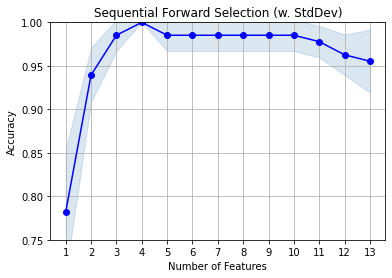

```
('alcohol', 'flavanoids', 'color_intensity', 'proline')
```

```python
from mlxtend.plotting import plot_sequential_feature_selection as plot_sfs
import matplotlib.pyplot as plt

fig1 = plot_sfs(sfs_forward.get_metric_dict(), ylabel='Accuracy')

plt.ylim([0.75, 1])
plt.title('Sequential Forward Selection (w. StdDev)')
plt.grid()
plt.show()
print(sfs_forward.k_feature_names_)
```

Including 4 features has the highest accuracy score. Therefore, 4 seems like a better choice for the number of features for this dataset. To know which features contribute to the high accuracy, we can create a dataframe of the metrics obtained from the sequential forward selection model as given below.

```python
pd.DataFrame.from_dict(sfs_forward.get_metric_dict()).T
```

|  | feature_idx | cv_scores | avg_score | feature_names | ci_bound | std_dev | std_err |
| --- | --- | --- | --- | --- | --- | --- | --- |
| 1 | (6,) | [0.8888888888888888, 0.8148148148148148, 0.666... | 0.781766 | (flavanoids,) | 0.0929145 | 0.0722906 | 0.0361453 |
| 2 | (6, 9) | [0.9629629629629629, 0.9629629629629629, 0.962... | 0.939316 | (flavanoids, color_intensity) | 0.0403729 | 0.0314115 | 0.0157057 |
| 3 | (6, 9, 12) | [0.9629629629629629, 0.9629629629629629, 1.0, ... | 0.985185 | (flavanoids, color_intensity, proline) | 0.0233208 | 0.0181444 | 0.00907218 |
| 4 | (0, 6, 9, 12) | [1.0, 1.0, 1.0, 1.0, 1.0] | 1 | (alcohol, flavanoids, color_intensity, proline) | 0 | 0 | 0 |
| 5 | (0, 1, 6, 9, 12) | [1.0, 0.9629629629629629, 0.9629629629629629, ... | 0.985185 | (alcohol, malic_acid, flavanoids, color_intens... | 0.0233208 | 0.0181444 | 0.00907218 |
| 6 | (0, 1, 4, 6, 9, 12) | [0.9629629629629629, 1.0, 0.9629629629629629, ... | 0.985185 | (alcohol, malic_acid, magnesium, flavanoids, c... | 0.0233208 | 0.0181444 | 0.00907218 |
| 7 | (0, 1, 4, 6, 9, 10, 12) | [0.9629629629629629, 1.0, 0.9629629629629629, ... | 0.985185 | (alcohol, malic_acid, magnesium, flavanoids, c... | 0.0233208 | 0.0181444 | 0.00907218 |
| 8 | (0, 1, 3, 4, 6, 9, 10, 12) | [0.9629629629629629, 1.0, 0.9629629629629629, ... | 0.985185 | (alcohol, malic_acid, alcalinity_of_ash, magne... | 0.0233208 | 0.0181444 | 0.00907218 |
| 9 | (0, 1, 3, 4, 6, 9, 10, 11, 12) | [0.9629629629629629, 1.0, 0.9629629629629629, ... | 0.985185 | (alcohol, malic_acid, alcalinity_of_ash, magne... | 0.0233208 | 0.0181444 | 0.00907218 |
| 10 | (0, 1, 2, 3, 4, 6, 9, 10, 11, 12) | [0.9629629629629629, 1.0, 0.9629629629629629, ... | 0.985185 | (alcohol, malic_acid, ash, alcalinity_of_ash, ... | 0.0233208 | 0.0181444 | 0.00907218 |
| 11 | (0, 1, 2, 3, 4, 6, 7, 9, 10, 11, 12) | [0.9629629629629629, 0.9629629629629629, 0.962... | 0.977778 | (alcohol, malic_acid, ash, alcalinity_of_ash, ... | 0.0233208 | 0.0181444 | 0.00907218 |
| 12 | (0, 1, 2, 3, 4, 6, 7, 8, 9, 10, 11, 12) | [0.9259259259259259, 0.9629629629629629, 0.962... | 0.962678 | (alcohol, malic_acid, ash, alcalinity_of_ash, ... | 0.0301159 | 0.0234312 | 0.0117156 |
| 13 | (0, 1, 2, 3, 4, 5, 6, 7, 8, 9, 10, 11, 12) | [0.9629629629629629, 0.8888888888888888, 0.962... | 0.955271 | (alcohol, malic_acid, ash, alcalinity_of_ash, ... | 0.0465725 | 0.036235 | 0.0181175 |

#### Exercise

1. Perform sequential backward selection.
2. Select `cv` = 10 and `k_features` = 7 for sequential forward selection and sequential backward selection. Identify the common features from feature set with highest accuracy score in each case.